# FCS file information

## FCS file information

> Input file name: 2016-07-08_PANEL 1_ZF_Group one_F1631269_003  
> Number of events: 876401

## Quality control analysis

### Summary

> The anomalies were removed from: Flow Rate and Flow Margin  
> Anomalies detected in total: **48.35** %  
> Number of high quality events: 452701

### Flow rate check

> **47.23** % anomalies detected in the flow rate check.

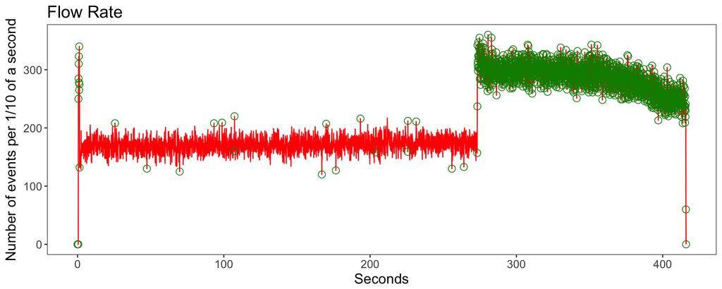

The plot reconstructs the flow rate with a resolution of 1/10 of a second. Anomalies in the flow rate are identified with an algorithm based on the generalied ESD outlier detection method. The anomalies are circled in green.

### Signals acquisition check

> **49.74** % anomalies detected in the signal aquisition check.

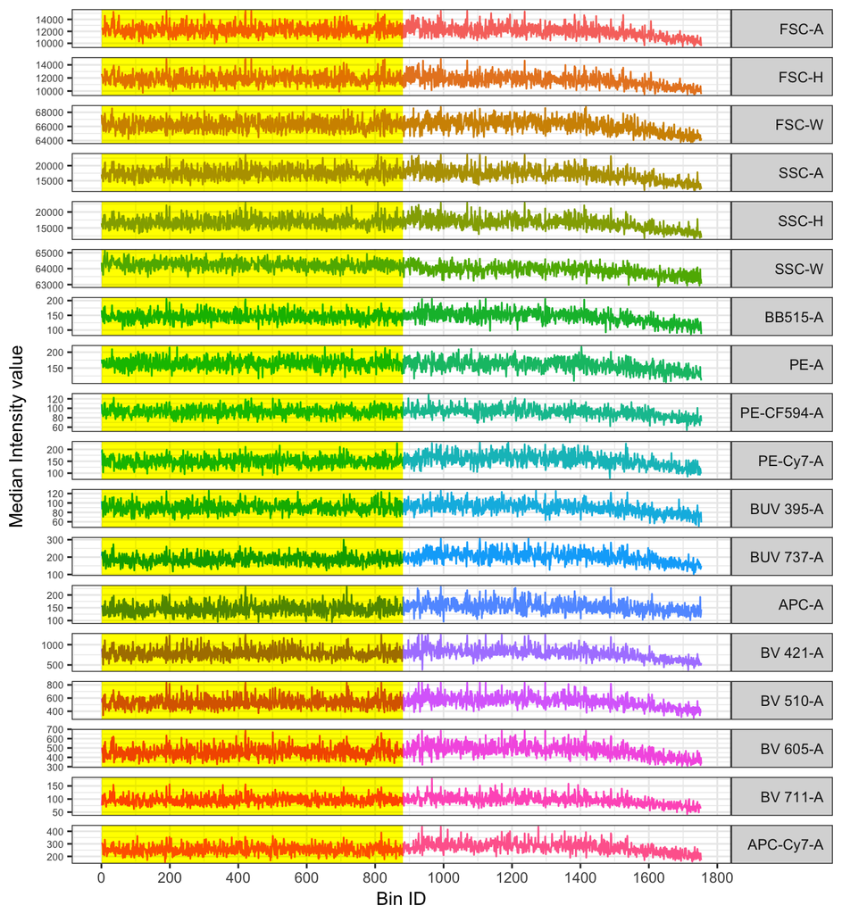

The more stable region selected consistent for all channels is highlighted in yellow. If the removal of outliers has been required before the execution of the changepoint analysis, the detected outliers are cicled in green.

The FCS file was divided in 1753 bins. The stable region is located between the bins 1 and 881.

##### More info on the changepoints detected:

Changepoints detected in channels with shifts in signal acquisition:

```
##               1    2    3
## BB515-A    1552
## PE-A       1541
## PE-CF594-A 1615
## PE-Cy7-A    918 1571
## BUV 395-A  1570
## BUV 737-A   918 1623
## APC-A       881 1539
## BV 421-A    923  938 1553
## BV 510-A    914  937 1615
## BV 605-A    906  938 1615
## BV 711-A   1550
## APC-Cy7-A   918 1537 1615
```

Channels excluded from the analysis: FSC-A, FSC-H, FSC-W, SSC-A, SSC-H, SSC-W.

### Dynamic range check

> **2.03** % anomalies detected in dynamic range check.

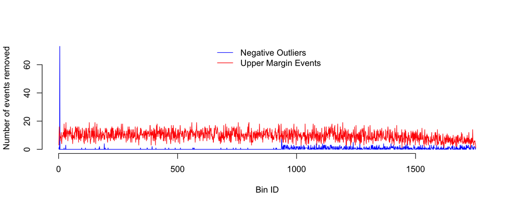

The plot shows where the anomalies occured the most. The x-axis scale is complementary to the one of the signal acquisition plot.

##### More info on the anomalies detected in the dynamic range check:

for each channel, The table shows the number of events that did not pass the dynamic range check:

```
##              lower_range upper_range
## FSC-A                  0        5212
## FSC-H                  0           0
## FSC-W                  0           9
## SSC-A                  0       15639
## SSC-H                  0           0
## SSC-W                  0          13
## BB515-A               57          49
## PE-A                  45          27
## PE-CF594-A            54          14
## PE-Cy7-A               1          30
## BUV 395-A             14         180
## BUV 737-A             25         177
## APC-A                 57          22
## BV 421-A             267        1100
## BV 510-A             173         694
## BV 605-A             188         439
## BV 711-A              27         176
## APC-Cy7-A             48          32
## total_SUM            956       23813
## total_UNIQUE         837       16966
```